# 5 Dimensionality reduction techniques

```
Intro from the IODS MOOC-page:
```

Actually, a fairly large selection of statistical methods can be listed under the title “*dimensionality reduction techniques*”. Most often (nearly always, that is!) the real-world phenomena are **multidimensional**: they may consist of not just two or three but 5 or 10 or 20 or 50 (or more) dimensions. Of course, we are living only in a three-dimensional (3D) world, so those multiple dimensions may really challenge our imagination. It would be easier **to reduce the number of dimensions** in one way or another.

We shall now learn the basics of two data science based ways of reducing the dimensions. The principal method here is **principal component analysis** (PCA), which reduces any number of measured (continuous) and correlated variables into a few uncorrelated components that collect together as much variance as possible from the original variables. The most important components can be then used for various purposes, e.g., drawing scatterplots and other fancy graphs that would be quite impossible to achieve with the original variables and too many dimensions.

**Multiple correspondence analysis** (MCA) and other variations of CA bring us similar possibilities in the world of **discrete variables**, even nominal scale (classified) variables, by finding a suitable transformation into continuous scales and then reducing the dimensions quite analogously with the PCA. The typical graphs show the original classes of the discrete variables on the same “map”, making it possible to reveal **connections** (correspondences) between different things that would be quite impossible to see from the corresponding cross tables (too many numbers!).

Briefly stated, these methods help to visualize and understand multidimensional phenomena by reducing their dimensionality that may first feel impossible to handle at all.

## 5.1 Principal Component Analysis

### 5.1.1 Introducing the dataset for PCA

> This chapter’s dataset originates from the United Nations Development Programme. The Human Development Index (HDI) was created for assessig the development of a country in another way than just economic growth. More information can be found on their [general data page](http://hdr.undp.org/en/content/human-development-index-hdi) and on [pdf about calculating the human development indices](http://hdr.undp.org/sites/default/files/hdr2015_technical_notes.pdf).

```r
# read the human data, row names as first column
human <- read.csv("./data/human.csv", row.names=1)
str(human)
```

```
## 'data.frame':    155 obs. of  8 variables:
##  $ Edu2.FM  : num  1.007 0.997 0.983 0.989 0.969 ...
##  $ Labo.FM  : num  0.891 0.819 0.825 0.884 0.829 ...
##  $ Life.Exp : num  81.6 82.4 83 80.2 81.6 80.9 80.9 79.1 82 81.8 ...
##  $ Edu.Exp  : num  17.5 20.2 15.8 18.7 17.9 16.5 18.6 16.5 15.9 19.2 ...
##  $ GNI      : int  64992 42261 56431 44025 45435 43919 39568 52947 42155 32689 ...
##  $ Mat.Mor  : int  4 6 6 5 6 7 9 28 11 8 ...
##  $ Ado.Birth: num  7.8 12.1 1.9 5.1 6.2 3.8 8.2 31 14.5 25.3 ...
##  $ Parli.F  : num  39.6 30.5 28.5 38 36.9 36.9 19.9 19.4 28.2 31.4 ...
```

The dataset consists 155 observations (i.e. **countries**) in 8 variables:

The data combines several indicators for the countries:

- **Country**: name of the country as row name
- **Health and knowledge**: `GNI`, `Life.Exp`, `Edu.Exp`, `Mat.Mor`, `Ado.Birth`
- **Empowerment**: `Parli.F`, `Edu2.FM`,`Labo.FM`

Most of the variable names have been shortened from the original data and two new variables (`Edu2.FM` and `Labo.FM`) were computed.

### 5.1.2 Graphical overview and summaries of the variables

```r
library(ggplot2) # for graphics
library(GGally)
library(corrplot)
library(dplyr)
summary(human)
```

```
##     Edu2.FM          Labo.FM          Life.Exp        Edu.Exp
##  Min.   :0.1717   Min.   :0.1857   Min.   :49.00   Min.   : 5.40
##  1st Qu.:0.7264   1st Qu.:0.5984   1st Qu.:66.30   1st Qu.:11.25
##  Median :0.9375   Median :0.7535   Median :74.20   Median :13.50
##  Mean   :0.8529   Mean   :0.7074   Mean   :71.65   Mean   :13.18
##  3rd Qu.:0.9968   3rd Qu.:0.8535   3rd Qu.:77.25   3rd Qu.:15.20
##  Max.   :1.4967   Max.   :1.0380   Max.   :83.50   Max.   :20.20
##       GNI            Mat.Mor         Ado.Birth         Parli.F
##  Min.   :   581   Min.   :   1.0   Min.   :  0.60   Min.   : 0.00
##  1st Qu.:  4198   1st Qu.:  11.5   1st Qu.: 12.65   1st Qu.:12.40
##  Median : 12040   Median :  49.0   Median : 33.60   Median :19.30
##  Mean   : 17628   Mean   : 149.1   Mean   : 47.16   Mean   :20.91
##  3rd Qu.: 24512   3rd Qu.: 190.0   3rd Qu.: 71.95   3rd Qu.:27.95
##  Max.   :123124   Max.   :1100.0   Max.   :204.80   Max.   :57.50
```

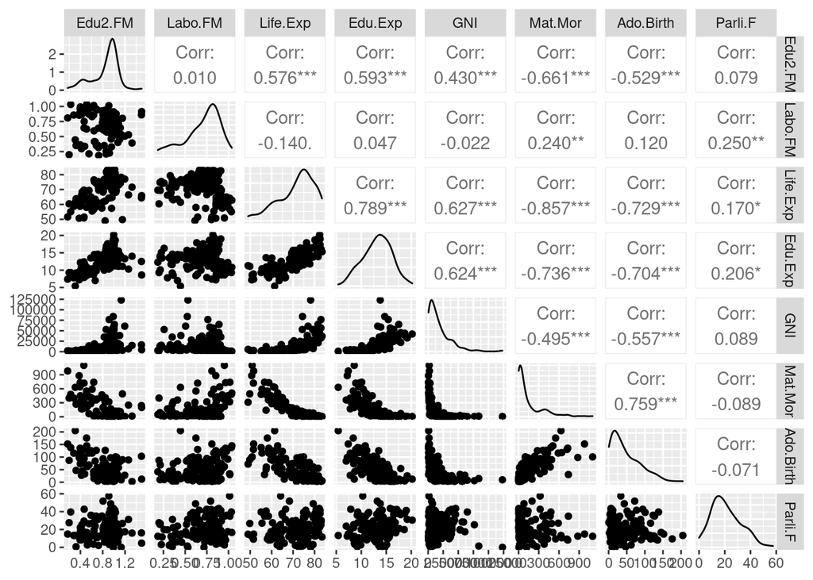

```r
ggpairs(human, upper = list(continuous = wrap("cor", family="sans"))) # graphical overview
```

There is much **skewness** present in the variable, i.e. only `Edu2.FM` and `Edu.Exp` are somewhat normally distributed. Many variables are strongly correlated as implied by the statistically significant correlation coefficients. The correlation can be visualized better with correlation plot:

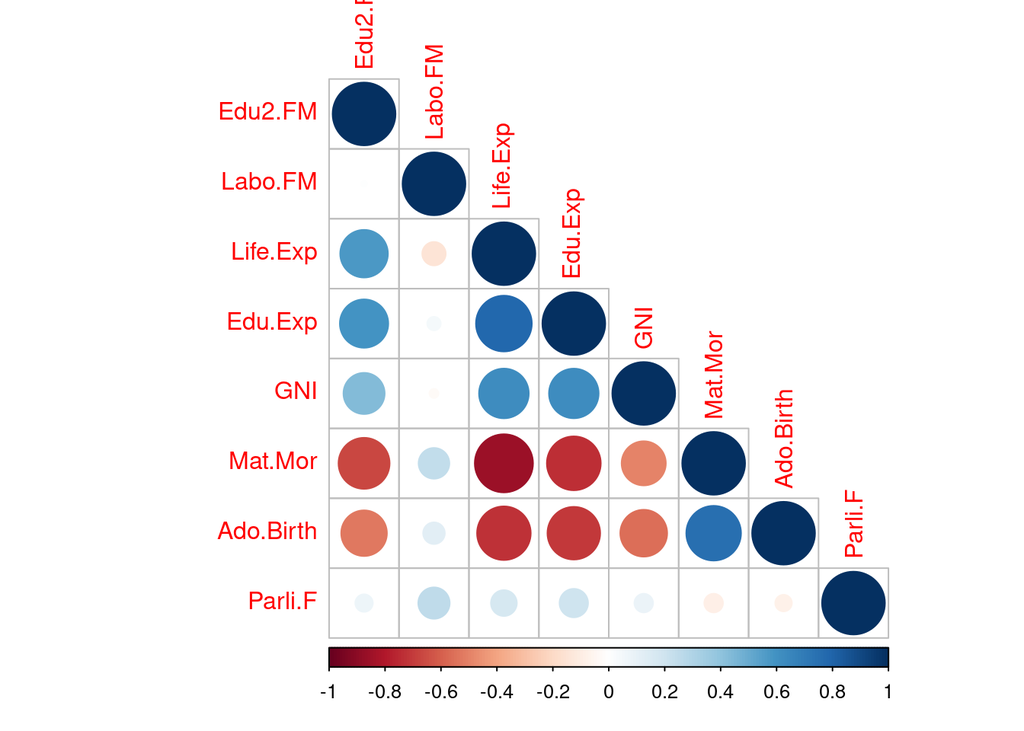

```r
# compute the correlation matrix and visualize it with corrplot
cor(human) %>% corrplot(type="lower") # lower correlation matrix, since symmetric
```

The correlation matrix gives us an idea of the relation of the variables, i.e. there seem to be great

- **negative correlations** between maternal mortality ratio and life expectency and expected years of schooling and ratio of secondary education in females/males (`Mat.Mor` and `Life.Exp`&`Edu.Exp`&`Edu2.FM`). Similarly with Adolescent birth rate `Ado.Birth`.
- **positive correlations** between Education expectency and Life expectency and Adolescent birth rate and Maternal mortality

Percentage of female representatives in parliament (`Parli.F`) and Ratio of labour force participation rate in females compared to males (`Labo.FM`) don’t seem to be correlated with any variable. There is, however, a slight correlation between them.

### 5.1.3 Principal Component Analysis

**Principal component analysis** (PCA) is a statistical procedure which reduces the number of dimensions in multivariate data. Reducing dimension is essential in representing the phenomenon of interest clearly without “too much” distracting information (non-related data, noise or random error).

The idea of PCA is to *transform* the data to a new space with equal or less number of dimensions (new features). These new features are called **principal components** (PC). The first PC captures the **maximum amount of variance** from the features in the original data. The second PC captures the **maximum amount of variability left** etc. All PC are **uncorrelated** and **orthogonal** to each other.

Since **PCA is sensitive to variance**, let us make two analyses: one without and one with standardized dataset.

### 5.1.4 PCA without standardization of data

```r
# PCA on non-standardized human data (with the SVD method)
pca_human <- prcomp(human)
# printing summary of PCA
s <- summary(pca_human)
s
```

```
## Importance of components:
##                              PC1      PC2   PC3   PC4   PC5   PC6    PC7    PC8
## Standard deviation     1.854e+04 185.5219 25.19 11.45 3.766 1.566 0.1912 0.1591
## Proportion of Variance 9.999e-01   0.0001  0.00  0.00 0.000 0.000 0.0000 0.0000
## Cumulative Proportion  9.999e-01   1.0000  1.00  1.00 1.000 1.000 1.0000 1.0000
```

```r
# print out rounded percetanges of variance captured by each PC
pca_pr <- round(100*s$importance[2, ], digits = 1)
pca_pr
```

```
## PC1 PC2 PC3 PC4 PC5 PC6 PC7 PC8
## 100   0   0   0   0   0   0   0
```

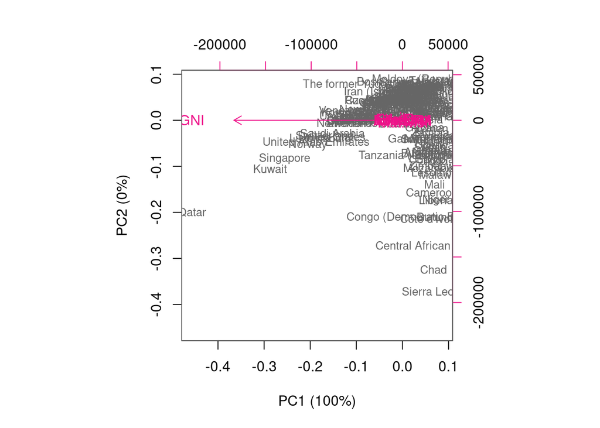

```r
# create object pc_lab to be used as axis labels
pc_lab <- paste0(names(pca_pr), " (", pca_pr, "%)")
# draw a biplot of the PC representation and the original variables
biplot(pca_human, choices = 1:2, cex=c(0.8,1), col=c("grey40","deeppink2"), xlab = pc_lab[1], ylab = pc_lab[2], caption="PC1 is the strongest")
```

### 5.1.5 PCA with standardization of data

```r
# standardize the variables by the function scale (the z-score)
human_std <- scale(human)
# print out summaries of the standardized variables (mean = 0)
summary(human_std)
```

```
##     Edu2.FM           Labo.FM           Life.Exp          Edu.Exp
##  Min.   :-2.8189   Min.   :-2.6247   Min.   :-2.7188   Min.   :-2.7378
##  1st Qu.:-0.5233   1st Qu.:-0.5484   1st Qu.:-0.6425   1st Qu.:-0.6782
##  Median : 0.3503   Median : 0.2316   Median : 0.3056   Median : 0.1140
##  Mean   : 0.0000   Mean   : 0.0000   Mean   : 0.0000   Mean   : 0.0000
##  3rd Qu.: 0.5958   3rd Qu.: 0.7350   3rd Qu.: 0.6717   3rd Qu.: 0.7126
##  Max.   : 2.6646   Max.   : 1.6632   Max.   : 1.4218   Max.   : 2.4730
##       GNI             Mat.Mor          Ado.Birth          Parli.F
##  Min.   :-0.9193   Min.   :-0.6992   Min.   :-1.1325   Min.   :-1.8203
##  1st Qu.:-0.7243   1st Qu.:-0.6496   1st Qu.:-0.8394   1st Qu.:-0.7409
##  Median :-0.3013   Median :-0.4726   Median :-0.3298   Median :-0.1403
##  Mean   : 0.0000   Mean   : 0.0000   Mean   : 0.0000   Mean   : 0.0000
##  3rd Qu.: 0.3712   3rd Qu.: 0.1932   3rd Qu.: 0.6030   3rd Qu.: 0.6127
##  Max.   : 5.6890   Max.   : 4.4899   Max.   : 3.8344   Max.   : 3.1850
```

```r
# perform principal component analysis (with the SVD method)
pca2_human <- prcomp(human_std)
# printing summary of PCA
s2 <- summary(pca2_human)
s2
```

```
## Importance of components:
##                           PC1    PC2     PC3     PC4     PC5     PC6     PC7
## Standard deviation     2.0708 1.1397 0.87505 0.77886 0.66196 0.53631 0.45900
## Proportion of Variance 0.5361 0.1624 0.09571 0.07583 0.05477 0.03595 0.02634
## Cumulative Proportion  0.5361 0.6984 0.79413 0.86996 0.92473 0.96069 0.98702
##                            PC8
## Standard deviation     0.32224
## Proportion of Variance 0.01298
## Cumulative Proportion  1.00000
```

```r
# print out rounded percetanges of variance captured by each PC
pca2_pr <- round(100*s2$importance[2, ], digits = 1)
pca2_pr
```

```
##  PC1  PC2  PC3  PC4  PC5  PC6  PC7  PC8
## 53.6 16.2  9.6  7.6  5.5  3.6  2.6  1.3
```

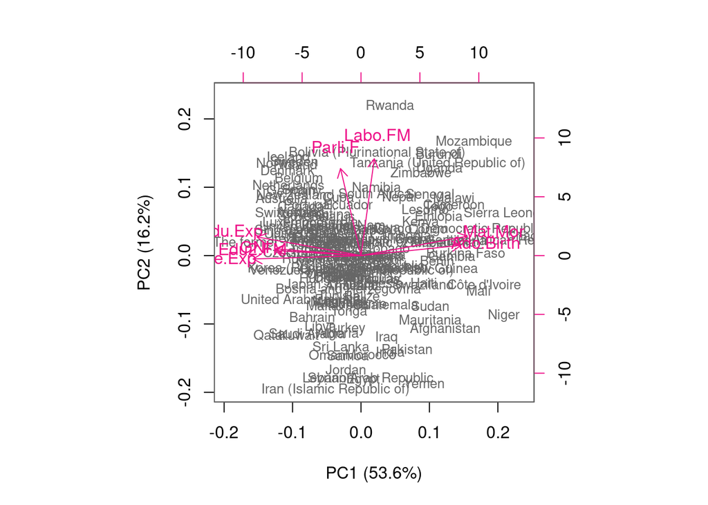

```r
# create object pc_lab to be used as axis labels
pc_lab2 <- paste0(names(pca2_pr), " (", pca2_pr, "%)")
# draw a biplot of the PC representation and the original variables
biplot(pca2_human, choices = 1:2, cex=c(0.8,1), col=c("grey40","deeppink2"), xlab = pc_lab2[1], ylab = pc_lab2[2], caption="After standardization of variables")
```

### 5.1.6 Interpreting the results

The results are *very different* based on whether or not the standardization was made.

Without normalization of data, there is practically only one PC which explains 100% of the variance in the data. The variable gross national income per capita (`GNI`) dominates the PCA due to its absolute values being 10- or even 100-fold larger than the other variables. Thus, as expected, **there is a crucial need for standardization**!

After standardization, the effect of other variables than just `GNI` becomes clearer. The first PC explains 53.6% of the variability and the second 16.2% covering roughly a total of 70% of the variability in the data. Out of the variables, `Parli.F` and `Labo.FM` have high positive correlation with PC2 (the angle between the y-axis is small) while all other variables have a high correlation with PC1 (x-axis). This kind of division could be observed already in the correlation plot earlier.

Regarding the interpretation of the dimensions in the standardized data PCA, it seems that PC1 is some general index for health and knowledge (“standard of living”) while PC2 is some female empowerment in the society.

## 5.2 Multiple Correspondence Analysis

While *PCA* reduced the dimension for *continuous* variables, **Multiple Correspondence Analysis** (MCA) is an analogous method for **categorical** variables.

### 5.2.1 Introducing the dataset for MCA

> The `tea` dataset (from the package `FactoMineR`) consists of tea consumption survey results from 300 tea consumers. For our purpose we will choose only six columns (the same as in the course DataCamp exercises).

```r
library(tidyr)
library(FactoMineR)
data("tea") # Load data tea from FactoMineR package
# column names to keep in the dataset
keep_columns <- c("Tea", "How", "how", "sugar", "where", "lunch")
# select the 'keep_columns' to create a new dataset
tea_time <- dplyr::select(tea, one_of(keep_columns))

# look at the structure of the data
str(tea_time)
```

```
## 'data.frame':    300 obs. of  6 variables:
##  $ Tea  : Factor w/ 3 levels "black","Earl Grey",..: 1 1 2 2 2 2 2 1 2 1 ...
##  $ How  : Factor w/ 4 levels "alone","lemon",..: 1 3 1 1 1 1 1 3 3 1 ...
##  $ how  : Factor w/ 3 levels "tea bag","tea bag+unpackaged",..: 1 1 1 1 1 1 1 1 2 2 ...
##  $ sugar: Factor w/ 2 levels "No.sugar","sugar": 2 1 1 2 1 1 1 1 1 1 ...
##  $ where: Factor w/ 3 levels "chain store",..: 1 1 1 1 1 1 1 1 2 2 ...
##  $ lunch: Factor w/ 2 levels "lunch","Not.lunch": 2 2 2 2 2 2 2 2 2 2 ...
```

Exploring our data reveals that we have 300 observations in 6 variables. All the variables are of type `factor` with several levels.

### 5.2.2 Graphical overview and a summary of variabless

```r
# numerical summary
summary(tea_time)
```

```
##         Tea         How                      how           sugar
##  black    : 74   alone:195   tea bag           :170   No.sugar:155
##  Earl Grey:193   lemon: 33   tea bag+unpackaged: 94   sugar   :145
##  green    : 33   milk : 63   unpackaged        : 36
##                  other:  9
##                   where           lunch
##  chain store         :192   lunch    : 44
##  chain store+tea shop: 78   Not.lunch:256
##  tea shop            : 30
##
```

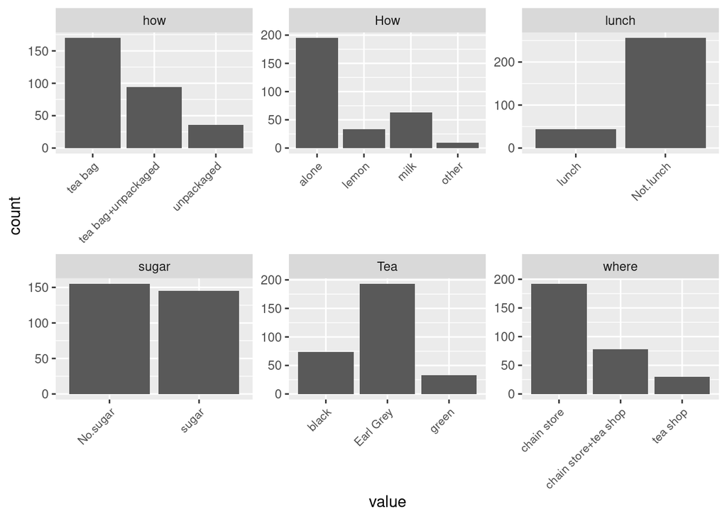

```r
# visualize the dataset
gather(tea_time) %>% ggplot(aes(value)) + facet_wrap("key", scales = "free") + geom_bar() + theme(axis.text.x = element_text(angle = 45, hjust = 1, size = 8))
```

All of the variables have a certain dominating factor except for `sugar` which evenly divided between *sugar* and *no sugar*.

### 5.2.3 Multiple Component Analysis

Now let’s perform a MCA to our `tea` dataset!

```r
# multiple correspondence analysis
mca <- MCA(tea_time, graph = FALSE)
# summary of the model
summary(mca)
```

```
##
## Call:
## MCA(X = tea_time, graph = FALSE)
##
##
## Eigenvalues
##                        Dim.1   Dim.2   Dim.3   Dim.4   Dim.5   Dim.6   Dim.7
## Variance               0.279   0.261   0.219   0.189   0.177   0.156   0.144
## % of var.             15.238  14.232  11.964  10.333   9.667   8.519   7.841
## Cumulative % of var.  15.238  29.471  41.435  51.768  61.434  69.953  77.794
##                        Dim.8   Dim.9  Dim.10  Dim.11
## Variance               0.141   0.117   0.087   0.062
## % of var.              7.705   6.392   4.724   3.385
## Cumulative % of var.  85.500  91.891  96.615 100.000
##
## Individuals (the 10 first)
##                       Dim.1    ctr   cos2    Dim.2    ctr   cos2    Dim.3
## 1                  | -0.298  0.106  0.086 | -0.328  0.137  0.105 | -0.327
## 2                  | -0.237  0.067  0.036 | -0.136  0.024  0.012 | -0.695
## 3                  | -0.369  0.162  0.231 | -0.300  0.115  0.153 | -0.202
## 4                  | -0.530  0.335  0.460 | -0.318  0.129  0.166 |  0.211
## 5                  | -0.369  0.162  0.231 | -0.300  0.115  0.153 | -0.202
## 6                  | -0.369  0.162  0.231 | -0.300  0.115  0.153 | -0.202
## 7                  | -0.369  0.162  0.231 | -0.300  0.115  0.153 | -0.202
## 8                  | -0.237  0.067  0.036 | -0.136  0.024  0.012 | -0.695
## 9                  |  0.143  0.024  0.012 |  0.871  0.969  0.435 | -0.067
## 10                 |  0.476  0.271  0.140 |  0.687  0.604  0.291 | -0.650
##                       ctr   cos2
## 1                   0.163  0.104 |
## 2                   0.735  0.314 |
## 3                   0.062  0.069 |
## 4                   0.068  0.073 |
## 5                   0.062  0.069 |
## 6                   0.062  0.069 |
## 7                   0.062  0.069 |
## 8                   0.735  0.314 |
## 9                   0.007  0.003 |
## 10                  0.643  0.261 |
##
## Categories (the 10 first)
```

[output cut: 16 more lines]

```
## lemon                3.226 |   1.329  14.771   0.218   8.081 |
## milk                 2.422 |   0.013   0.003   0.000   0.116 |
## other                5.534 |  -2.524  14.526   0.197  -7.676 |
## tea bag             -6.941 |  -0.065   0.183   0.006  -1.287 |
## tea bag+unpackaged  11.956 |   0.019   0.009   0.000   0.226 |
## unpackaged          -6.482 |   0.257   0.602   0.009   1.640 |
##
## Categorical variables (eta2)
##                      Dim.1 Dim.2 Dim.3
## Tea                | 0.126 0.108 0.410 |
## How                | 0.076 0.190 0.394 |
## how                | 0.708 0.522 0.010 |
## sugar              | 0.065 0.001 0.336 |
## where              | 0.702 0.681 0.055 |
## lunch              | 0.000 0.064 0.111 |
```

The output of the MCA summary is somewhat lengthy. However, it contains information about

- **Eigenvalues**: the variances and the percentage of variances retained by each dimension
- **Individuals**: the individuals’ coordinates, the individuals contribution (%) on the dimension and the cos2 (the squared correlations) on the dimensions
- **Categories**: the coordinates of the variable categories, the contribution(%) the cos2 (the squared correlations) and v.test value. The v.test follows normal distribution: if the value is below/above +/- 1.96, the coordinate is significantly different from zero.
- **Categorical variables**: the squared correlation between each variable and the dimensions. If the value is close to 1 it indicates strong link with the variable and dimension.

Here it seems there is no dominating dimensions (the first and the second dimension explain only about 15% and 14% of the variation, respectively).

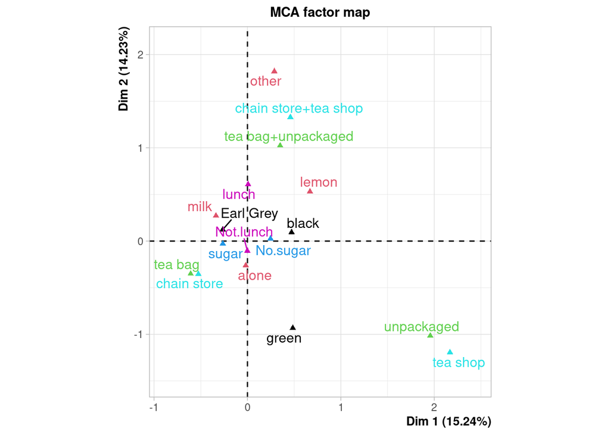

```r
# visualize MCA
plot(mca, invisible=c("ind"), habillage = "quali")
```

Visualizing the data does not give a better insight about the matter either. By interpreting the biggest ranges in the dimentions, the first dimension might tell about how the tea is consumed (in a tea bag vs. unpackaged) while the second dimension tells where the tea is bought (tea shop vs. chain store). Observing the clusters, it seems that e.g. `unpackaged` and `tea shop` are very similar as well as `tea bag` and `chain store` tea have a connection. However, many of the connections remain fuzzy. It is sometimes possible that despite all the advanced methods, obtaining insights from the data is difficult.